# Exploratory Data Analysis of Aadhaar Enrolment Data

# Top 10 Districts by Enrollment

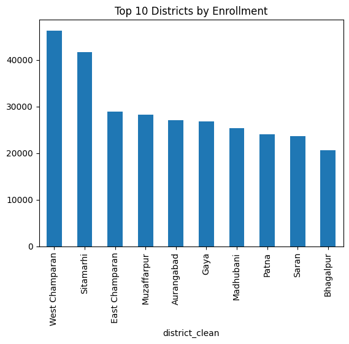

```python
top_districts = df.groupby('district_clean')['total_enrollment'] \
                  .sum().sort_values(ascending=False).head(10)

top_districts.plot(kind='bar')
plt.title('Top 10 Districts by Enrollment')
plt.show()
```

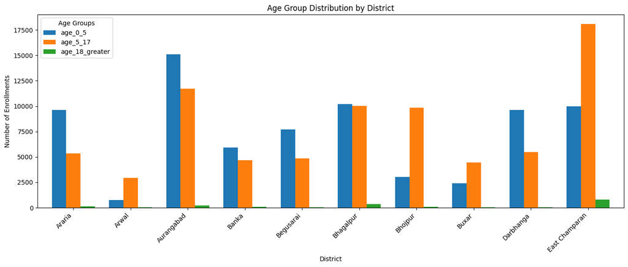

```python
import matplotlib.pyplot as plt

district_age = df.groupby('district_clean')[
    ['age_0_5','age_5_17','age_18_greater']
].sum().head(10)

ax = district_age.plot(
    kind='bar',
    stacked=False,      # important → no overlap
    figsize=(14,6),
    width=0.75
)

plt.title('Age Group Distribution by District')
plt.xlabel('District')
plt.ylabel('Number of Enrollments')
plt.xticks(rotation=45, ha='right')
plt.legend(title='Age Groups')
plt.tight_layout()
plt.show()
```

# 📊 Enrollment Variability Across Districts

**This bar chart highlights the top 10 districts with the highest standard deviation in total enrollment, indicating significant variability over time. High volatility suggests inconsistent enrollment patterns, possibly due to seasonal drives, migration, or administrative factors.**

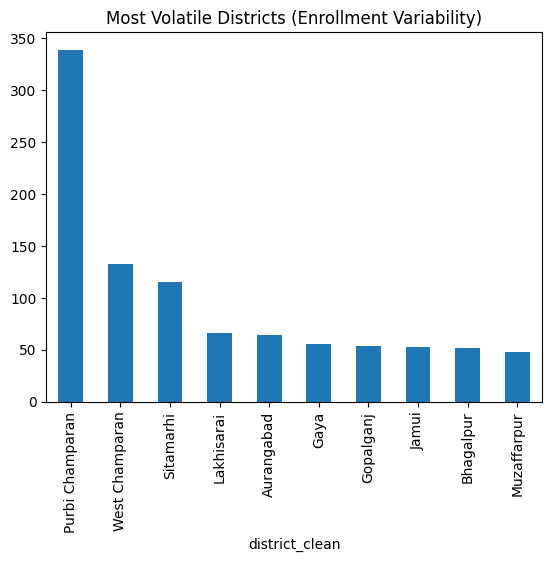

```python
district_std = df.groupby('district_clean')['total_enrollment'].std()

district_std.sort_values(ascending=False).head(10).plot(kind='bar')
plt.title('Most Volatile Districts (Enrollment Variability)')
plt.show()
```

### 📌 District-wise Enrollment Ranking Analysis

This analysis ranks districts based on their **total Aadhaar enrollment** over the entire study period.

```python
district_rank = df.groupby('district_clean')['total_enrollment'].sum() \
                  .rank(ascending=False)

district_rank.sort_values().head(10)
```

```
district_clean
West Champaran     1.0
Sitamarhi          2.0
East Champaran     3.0
Muzaffarpur        4.0
Aurangabad         5.0
Gaya               6.0
Madhubani          7.0
Patna              8.0
Saran              9.0
Bhagalpur         10.0
Name: total_enrollment, dtype: float64
```

We performed univariate, bivariate, and multivariate analysis to study  
enrollment distribution across states, districts, and age groups.  
Advanced analysis included district-level volatility, age composition,  
time-based trends, and flag-based segmentation to uncover hidden patterns.

# Uttar Pradesh

```python
# Extracting rows where state is Uttar Pradesh
df_uttarpradesh= df[(df['state_clean']=='Uttar Pradesh')]
df_uttarpradesh
```

|  | date | state | district | pincode | age_0_5 | age_5_17 | age_18_greater | year | month | month_name | state_clean | total_enrollment | district_clean |
| --- | --- | --- | --- | --- | --- | --- | --- | --- | --- | --- | --- | --- | --- |
| 2 | 2025-03-09 | Uttar Pradesh | Kanpur Nagar | 208001 | 29 | 82 | 12 | 2025 | 3 | Mar | Uttar Pradesh | 123 | NaN |
| 3 | 2025-03-09 | Uttar Pradesh | Aligarh | 202133 | 62 | 29 | 15 | 2025 | 3 | Mar | Uttar Pradesh | 106 | NaN |
| 7 | 2025-03-09 | Uttar Pradesh | Bahraich | 271865 | 26 | 60 | 14 | 2025 | 3 | Mar | Uttar Pradesh | 100 | NaN |
| 8 | 2025-03-09 | Uttar Pradesh | Firozabad | 283204 | 28 | 26 | 10 | 2025 | 3 | Mar | Uttar Pradesh | 64 | NaN |
| 10 | 2025-03-09 | Uttar Pradesh | Maharajganj | 273164 | 31 | 70 | 13 | 2025 | 3 | Mar | Uttar Pradesh | 114 | NaN |
| ... | ... | ... | ... | ... | ... | ... | ... | ... | ... | ... | ... | ... | ... |
| 1005743 | 2025-12-31 | Uttar Pradesh | Varanasi | 221002 | 10 | 18 | 0 | 2025 | 12 | Dec | Uttar Pradesh | 28 | NaN |
| 1005744 | 2025-12-31 | Uttar Pradesh | Varanasi | 221104 | 4 | 11 | 0 | 2025 | 12 | Dec | Uttar Pradesh | 15 | NaN |
| 1005745 | 2025-12-31 | Uttar Pradesh | Varanasi | 221107 | 1 | 15 | 0 | 2025 | 12 | Dec | Uttar Pradesh | 16 | NaN |
| 1005746 | 2025-12-31 | Uttar Pradesh | Varanasi | 221207 | 1 | 9 | 0 | 2025 | 12 | Dec | Uttar Pradesh | 10 | NaN |
| 1005747 | 2025-12-31 | Uttar Pradesh | Varanasi | 221313 | 1 | 0 | 0 | 2025 | 12 | Dec | Uttar Pradesh | 1 | NaN |

108066 rows × 13 columns

```python
# Total unique districts in Uttar Pradesh
df_uttarpradesh['district'].nunique()
```

```
89
```

```python
# # Same District have more than one spelling so we have to map them
df_uttarpradesh['district'].unique()
```

```
array(['Kanpur Nagar', 'Aligarh', 'Bahraich', 'Firozabad', 'Maharajganj',
       'Ghaziabad', 'Gautam Buddha Nagar', 'Lucknow', 'Agra', 'Unnao',
       'Saharanpur', 'Jaunpur', 'Gorakhpur', 'Bulandshahr', 'Mathura',
       'Banda', 'Kheri', 'Budaun', 'Kanpur Dehat', 'Varanasi', 'Baghpat',
       'Fatehpur', 'Etawah', 'Shamli', 'Balrampur', 'Bara Banki',
       'Shahjahanpur', 'Gonda', 'Bareilly', 'Sitapur', 'Sultanpur',
       'Shrawasti', 'Chandauli', 'Mainpuri', 'Muzaffarnagar',
       'Siddharthnagar', 'Ambedkar Nagar', 'Pilibhit', 'Kaushambi',
       'Jalaun', 'Etah', 'Meerut', 'Basti', 'Azamgarh', 'Rampur',
       'Moradabad', 'Amroha', 'Bijnor', 'Deoria', 'Prayagraj', 'Lalitpur',
       'Hapur', 'Hathras', 'Kushinagar', 'Shravasti', 'Farrukhabad',
       'Hardoi', 'Ayodhya', 'Siddharth Nagar', 'Barabanki', 'Sambhal',
       'Jhansi', 'Kasganj', 'Kannauj', 'Kushi Nagar', 'Allahabad',
       'Amethi', 'Auraiya', 'Ballia', 'Bhadohi', 'Chitrakoot', 'Faizabad',
       'Ghazipur', 'Mahoba', 'Mau', 'Mirzapur', 'Pratapgarh',
       'Rae Bareli', 'Sant Kabir Nagar', 'Sant Ravidas Nagar',
       'Sonbhadra', 'Bulandshahar', 'Hamirpur', 'Jyotiba Phule Nagar',
       'Sant Ravidas Nagar Bhadohi', 'Raebareli', 'Mahrajganj',
       'Kushinagar *', 'Bagpat'], dtype=object)
```

# Mapping District

```python
df_uttarpradesh['district_clean'] = (
    df_uttarpradesh['district']
    .str.lower()
    .str.strip()
    .str.replace(r'\*', '', regex=True)
    .str.replace(r'\(.*?\)', '', regex=True)
    .str.replace(r'[^a-z\s]', '', regex=True)
)
```

```python
## District mapping Uttar Pradesh
district_standard_map = {
    "bara banki": "Barabanki",
    "barabanki": "Barabanki",

    "bulandshahar": "Bulandshahr",
    "bulandshahr": "Bulandshahr",

    "siddharth nagar": "Siddharthnagar",
    "siddharthnagar": "Siddharthnagar",

    "kushi nagar": "Kushinagar",
    "kushinagar *": "Kushinagar",
    "kushinagar": "Kushinagar",

    "shrawasti": "Shravasti",
    "shravasti": "Shravasti",

    "mahrajganj": "Maharajganj",
    "maharajganj": "Maharajganj",

    "sant ravidas nagar bhadohi": "Bhadohi",
    "sant ravidas nagar": "Bhadohi",
    "bhadohi": "Bhadohi",

    "jyotiba phule nagar": "Amroha",
    "amroha": "Amroha",

    "allahabad": "Prayagraj",
    "prayagraj": "Prayagraj",

    "faizabad": "Ayodhya",
    "ayodhya": "Ayodhya",

    "rae bareli": "Raebareli",
    "raebareli": "Raebareli",

    "bagpat": "Baghpat",
    "baghpat": "Baghpat"
}
```

```python
df['district_clean'] = (
    df['district']
    .apply(clean_name)
    .map(district_standard_map)
    .fillna(df_uttarpradesh['district'])

)
```

```python
## Remaining unmapped
df_uttarpradesh[df_uttarpradesh['district_clean'].isna()]['district'].unique()
# count check
df_uttarpradesh['district_clean'].nunique()
```

```
89
```

```python
df_uttarpradesh = df[df['state_clean']=='Uttar Pradesh']
df_uttarpradesh
```

|  | date | state | district | pincode | age_0_5 | age_5_17 | age_18_greater | year | month | month_name | state_clean | total_enrollment | district_clean |
| --- | --- | --- | --- | --- | --- | --- | --- | --- | --- | --- | --- | --- | --- |
| 2 | 2025-03-09 | Uttar Pradesh | Kanpur Nagar | 208001 | 29 | 82 | 12 | 2025 | 3 | Mar | Uttar Pradesh | 123 | Kanpur Nagar |
| 3 | 2025-03-09 | Uttar Pradesh | Aligarh | 202133 | 62 | 29 | 15 | 2025 | 3 | Mar | Uttar Pradesh | 106 | Aligarh |
| 7 | 2025-03-09 | Uttar Pradesh | Bahraich | 271865 | 26 | 60 | 14 | 2025 | 3 | Mar | Uttar Pradesh | 100 | Bahraich |
| 8 | 2025-03-09 | Uttar Pradesh | Firozabad | 283204 | 28 | 26 | 10 | 2025 | 3 | Mar | Uttar Pradesh | 64 | Firozabad |
| 10 | 2025-03-09 | Uttar Pradesh | Maharajganj | 273164 | 31 | 70 | 13 | 2025 | 3 | Mar | Uttar Pradesh | 114 | Maharajganj |
| ... | ... | ... | ... | ... | ... | ... | ... | ... | ... | ... | ... | ... | ... |
| 1005743 | 2025-12-31 | Uttar Pradesh | Varanasi | 221002 | 10 | 18 | 0 | 2025 | 12 | Dec | Uttar Pradesh | 28 | Varanasi |
| 1005744 | 2025-12-31 | Uttar Pradesh | Varanasi | 221104 | 4 | 11 | 0 | 2025 | 12 | Dec | Uttar Pradesh | 15 | Varanasi |
| 1005745 | 2025-12-31 | Uttar Pradesh | Varanasi | 221107 | 1 | 15 | 0 | 2025 | 12 | Dec | Uttar Pradesh | 16 | Varanasi |
| 1005746 | 2025-12-31 | Uttar Pradesh | Varanasi | 221207 | 1 | 9 | 0 | 2025 | 12 | Dec | Uttar Pradesh | 10 | Varanasi |
| 1005747 | 2025-12-31 | Uttar Pradesh | Varanasi | 221313 | 1 | 0 | 0 | 2025 | 12 | Dec | Uttar Pradesh | 1 | Varanasi |

108066 rows × 13 columns

```python
# Check Bihar-specific unmapped districts
df_uttarpradesh_unmapped = df_uttarpradesh[df_uttarpradesh['district_clean'].isna()]
print(f"Unmapped Uttar Pradesh districts count: {len(df_uttarpradesh_unmapped)}")
df_uttarpradesh_unmapped['district'].unique()
```

```
Unmapped Uttar Pradesh districts count: 0
```

```
array([], dtype=object)
```

```python
# Final unique districts in Uttar Pradesh after cleaning
df_uttarpradesh['district_clean'].unique()
```

```
array(['Kanpur Nagar', 'Aligarh', 'Bahraich', 'Firozabad', 'Maharajganj',
       'Ghaziabad', 'Gautam Buddha Nagar', 'Lucknow', 'Agra', 'Unnao',
       'Saharanpur', 'Jaunpur', 'Gorakhpur', 'Bulandshahr', 'Mathura',
       'Banda', 'Kheri', 'Budaun', 'Kanpur Dehat', 'Varanasi', 'Baghpat',
       'Fatehpur', 'Etawah', 'Shamli', 'Balrampur', 'Barabanki',
       'Shahjahanpur', 'Gonda', 'Bareilly', 'Sitapur', 'Sultanpur',
       'Shravasti', 'Chandauli', 'Mainpuri', 'Muzaffarnagar',
       'Siddharthnagar', 'Ambedkar Nagar', 'Pilibhit', 'Kaushambi',
       'Jalaun', 'Etah', 'Meerut', 'Basti', 'Azamgarh', 'Rampur',
       'Moradabad', 'Amroha', 'Bijnor', 'Deoria', 'Prayagraj', 'Lalitpur',
       'Hapur', 'Hathras', 'Kushinagar', 'Farrukhabad', 'Hardoi',
       'Ayodhya', 'Sambhal', 'Jhansi', 'Kasganj', 'Kannauj', 'Amethi',
       'Auraiya', 'Ballia', 'Bhadohi', 'Chitrakoot', 'Ghazipur', 'Mahoba',
       'Mau', 'Mirzapur', 'Pratapgarh', 'Raebareli', 'Sant Kabir Nagar',
       'Sant Ravidas Nagar', 'Sonbhadra', 'Hamirpur',
       'Jyotiba Phule Nagar', 'Sant Ravidas Nagar Bhadohi'], dtype=object)
```

```python
# Total unique districts in Uttar Pradesh after cleaning
df_uttarpradesh['district_clean'].nunique()
```

```
78
```

```python
# Check unique pincodes per district in Uttar Pradesh
pincode_check_UP = df_uttarpradesh.groupby('district_clean')['pincode'].nunique().reset_index(name='unique_pincodes')
pincode_check_UP
```

|  | district_clean | unique_pincodes |
| --- | --- | --- |
| 0 | Agra | 29 |
| 1 | Aligarh | 39 |
| 2 | Ambedkar Nagar | 34 |
| 3 | Amethi | 39 |
| 4 | Amroha | 14 |
| ... | ... | ... |
| 73 | Sitapur | 25 |
| 74 | Sonbhadra | 20 |
| 75 | Sultanpur | 35 |
| 76 | Unnao | 31 |
| 77 | Varanasi | 42 |

78 rows × 2 columns

```python
# Pincode associated with multiple districts in Uttar Pradesh
pin_district_count_UP = (
    df_uttarpradesh.groupby('pincode')['district_clean']
    .nunique()
    .reset_index(name='district_count')
)
```

```python
pin_district_count_UP
```

|  | pincode | district_count |
| --- | --- | --- |
| 0 | 121705 | 1 |
| 1 | 201001 | 2 |
| 2 | 201002 | 2 |
| 3 | 201003 | 1 |
| 4 | 201004 | 1 |
| ... | ... | ... |
| 1732 | 285203 | 1 |
| 1733 | 285204 | 1 |
| 1734 | 285205 | 2 |
| 1735 | 285206 | 1 |
| 1736 | 285223 | 2 |

1737 rows × 2 columns

```python
# Extract problematic pincodes (associated with >1 district)
problem_pins_UP = pin_district_count_UP[
    pin_district_count_UP['district_count'] > 1
]
```

```python
problem_pins_UP
```

|  | pincode | district_count |
| --- | --- | --- |
| 1 | 201001 | 2 |
| 2 | 201002 | 2 |
| 5 | 201005 | 2 |
| 6 | 201006 | 2 |
| 7 | 201007 | 2 |
| ... | ... | ... |
| 1713 | 284403 | 2 |
| 1724 | 285125 | 2 |
| 1725 | 285126 | 2 |
| 1734 | 285205 | 2 |
| 1736 | 285223 | 2 |

276 rows × 2 columns

```python
# Get all records with problematic pincodes(flagged records)
df_flagged_UP = df_uttarpradesh.merge(
    problem_pins_UP[['pincode']],
    on='pincode',
    how='inner'
)
```

```python
df_flagged_UP
```

|  | date | state | district | pincode | age_0_5 | age_5_17 | age_18_greater | year | month | month_name | state_clean | total_enrollment | district_clean |
| --- | --- | --- | --- | --- | --- | --- | --- | --- | --- | --- | --- | --- | --- |
| 0 | 2025-03-09 | Uttar Pradesh | Kanpur Nagar | 208001 | 29 | 82 | 12 | 2025 | 3 | Mar | Uttar Pradesh | 123 | Kanpur Nagar |
| 1 | 2025-03-09 | Uttar Pradesh | Bahraich | 271865 | 26 | 60 | 14 | 2025 | 3 | Mar | Uttar Pradesh | 100 | Bahraich |
| 2 | 2025-03-09 | Uttar Pradesh | Ghaziabad | 201102 | 50 | 113 | 11 | 2025 | 3 | Mar | Uttar Pradesh | 174 | Ghaziabad |
| 3 | 2025-03-15 | Uttar Pradesh | Ghaziabad | 201001 | 33 | 125 | 16 | 2025 | 3 | Mar | Uttar Pradesh | 174 | Ghaziabad |
| 4 | 2025-03-15 | Uttar Pradesh | Ghaziabad | 201102 | 19 | 146 | 30 | 2025 | 3 | Mar | Uttar Pradesh | 195 | Ghaziabad |
| ... | ... | ... | ... | ... | ... | ... | ... | ... | ... | ... | ... | ... | ... |
| 23227 | 2025-12-31 | Uttar Pradesh | Siddharthnagar | 272152 | 3 | 31 | 1 | 2025 | 12 | Dec | Uttar Pradesh | 35 | Siddharthnagar |
| 23228 | 2025-12-31 | Uttar Pradesh | Sultanpur | 227806 | 3 | 2 | 0 | 2025 | 12 | Dec | Uttar Pradesh | 5 | Sultanpur |
| 23229 | 2025-12-31 | Uttar Pradesh | Sultanpur | 227808 | 9 | 11 | 0 | 2025 | 12 | Dec | Uttar Pradesh | 20 | Sultanpur |
| 23230 | 2025-12-31 | Uttar Pradesh | Unnao | 209801 | 25 | 65 | 0 | 2025 | 12 | Dec | Uttar Pradesh | 90 | Unnao |
| 23231 | 2025-12-31 | Uttar Pradesh | Unnao | 241504 | 26 | 32 | 0 | 2025 | 12 | Dec | Uttar Pradesh | 58 | Unnao |

23232 rows × 13 columns

```python
# Summary of flagged records by district and pincode(for review)
flagged_pincode_UP=df_flagged_UP.groupby(['district_clean','pincode'])[['age_0_5','age_5_17','age_18_greater']].sum().reset_index()
# flagged_pincode_UP.to_excel('flagged_pincode_UP_domain.xlsx')
```

```python
# Add total enrollment column to flagged_pincode
flagged_pincode_UP['total_enrollment']=flagged_pincode_UP['age_0_5']+flagged_pincode_UP['age_5_17']+flagged_pincode['age_18_greater']
flagged_pincode_UP
```

|  | district_clean | pincode | age_0_5 | age_5_17 | age_18_greater | total_enrollment |
| --- | --- | --- | --- | --- | --- | --- |
| 0 | Aligarh | 202001 | 6212 | 5201 | 265 | 11414.0 |
| 1 | Aligarh | 202002 | 801 | 750 | 22 | 1551.0 |
| 2 | Aligarh | 202121 | 188 | 136 | 1 | 324.0 |
| 3 | Aligarh | 202139 | 0 | 2 | 0 | 16.0 |
| 4 | Aligarh | 202150 | 66 | 29 | 0 | 101.0 |
| ... | ... | ... | ... | ... | ... | ... |
| 571 | Varanasi | 221011 | 363 | 520 | 72 | NaN |
| 572 | Varanasi | 221101 | 532 | 1020 | 19 | NaN |
| 573 | Varanasi | 221116 | 46 | 58 | 0 | NaN |
| 574 | Varanasi | 232104 | 1 | 1 | 0 | NaN |
| 575 | Varanasi | 232105 | 0 | 1 | 0 | NaN |

576 rows × 6 columns

```python
flagged_pincode_UP['total_enrollment'] = (
	flagged_pincode_UP['age_0_5'] +
	flagged_pincode_UP['age_5_17'] +
	flagged_pincode_UP['age_18_greater']
)

idx = (
	flagged_pincode_UP
	.dropna(subset=['total_enrollment'])
	.groupby('pincode')['total_enrollment']
	.idxmax()
)

df_filtered_UP = flagged_pincode_UP.loc[idx]
df_filtered_UP
```

|  | district_clean | pincode | age_0_5 | age_5_17 | age_18_greater | total_enrollment |
| --- | --- | --- | --- | --- | --- | --- |
| 213 | Ghaziabad | 201001 | 2479 | 1991 | 73 | 4543 |
| 214 | Ghaziabad | 201002 | 553 | 546 | 40 | 1139 |
| 215 | Ghaziabad | 201005 | 732 | 553 | 31 | 1316 |
| 216 | Ghaziabad | 201006 | 111 | 36 | 4 | 151 |
| 217 | Ghaziabad | 201007 | 153 | 129 | 3 | 285 |
| ... | ... | ... | ... | ... | ... | ... |
| 366 | Lalitpur | 284403 | 1011 | 251 | 18 | 1280 |
| 283 | Jalaun | 285125 | 130 | 124 | 3 | 257 |
| 284 | Jalaun | 285126 | 99 | 72 | 2 | 173 |
| 285 | Jalaun | 285205 | 417 | 229 | 31 | 677 |
| 286 | Jalaun | 285223 | 34 | 34 | 0 | 68 |

276 rows × 6 columns

```python
# Creating a flag for pincodes associated with multiple districts
df_uttarpradesh['pin_multi_district_flag_UP']=(
    df_uttarpradesh.groupby('pincode')['district_clean']
    .transform('nunique')>1
)
```

```python
# Creating a flag for pincodes associated with multiple districts
pin_district_map = (
    df_uttarpradesh[df_uttarpradesh['pin_multi_district_flag_UP']]
    .groupby('pincode')['district_clean']  # noqa: SC100
    .unique()
    .reset_index()
)
```

```python
## monthly enrolment check
df_uttarpradesh['month'] = df_uttarpradesh['date'].dt.month.astype(str).str.zfill(2)
df_uttarpradesh
```

|  | date | state | district | pincode | age_0_5 | age_5_17 | age_18_greater | year | month | month_name | state_clean | total_enrollment | district_clean | pin_multi_district_flag_UP |
| --- | --- | --- | --- | --- | --- | --- | --- | --- | --- | --- | --- | --- | --- | --- |
| 2 | 2025-03-09 | Uttar Pradesh | Kanpur Nagar | 208001 | 29 | 82 | 12 | 2025 | 03 | Mar | Uttar Pradesh | 123 | Kanpur Nagar | True |
| 3 | 2025-03-09 | Uttar Pradesh | Aligarh | 202133 | 62 | 29 | 15 | 2025 | 03 | Mar | Uttar Pradesh | 106 | Aligarh | False |
| 7 | 2025-03-09 | Uttar Pradesh | Bahraich | 271865 | 26 | 60 | 14 | 2025 | 03 | Mar | Uttar Pradesh | 100 | Bahraich | True |
| 8 | 2025-03-09 | Uttar Pradesh | Firozabad | 283204 | 28 | 26 | 10 | 2025 | 03 | Mar | Uttar Pradesh | 64 | Firozabad | False |
| 10 | 2025-03-09 | Uttar Pradesh | Maharajganj | 273164 | 31 | 70 | 13 | 2025 | 03 | Mar | Uttar Pradesh | 114 | Maharajganj | False |
| ... | ... | ... | ... | ... | ... | ... | ... | ... | ... | ... | ... | ... | ... | ... |
| 1005743 | 2025-12-31 | Uttar Pradesh | Varanasi | 221002 | 10 | 18 | 0 | 2025 | 12 | Dec | Uttar Pradesh | 28 | Varanasi | False |
| 1005744 | 2025-12-31 | Uttar Pradesh | Varanasi | 221104 | 4 | 11 | 0 | 2025 | 12 | Dec | Uttar Pradesh | 15 | Varanasi | False |
| 1005745 | 2025-12-31 | Uttar Pradesh | Varanasi | 221107 | 1 | 15 | 0 | 2025 | 12 | Dec | Uttar Pradesh | 16 | Varanasi | False |
| 1005746 | 2025-12-31 | Uttar Pradesh | Varanasi | 221207 | 1 | 9 | 0 | 2025 | 12 | Dec | Uttar Pradesh | 10 | Varanasi | False |
| 1005747 | 2025-12-31 | Uttar Pradesh | Varanasi | 221313 | 1 | 0 | 0 | 2025 | 12 | Dec | Uttar Pradesh | 1 | Varanasi | False |

108066 rows × 14 columns

```python
# Dropping Date District and state as we have District clean State clean
df_uttarpradesh_cleaned=df_uttarpradesh.drop(columns=['date','district','state'], axis=1)
df_uttarpradesh_cleaned
```

|  | pincode | age_0_5 | age_5_17 | age_18_greater | year | month | month_name | state_clean | total_enrollment | district_clean | pin_multi_district_flag_UP |
| --- | --- | --- | --- | --- | --- | --- | --- | --- | --- | --- | --- |
| 2 | 208001 | 29 | 82 | 12 | 2025 | 03 | Mar | Uttar Pradesh | 123 | Kanpur Nagar | True |
| 3 | 202133 | 62 | 29 | 15 | 2025 | 03 | Mar | Uttar Pradesh | 106 | Aligarh | False |
| 7 | 271865 | 26 | 60 | 14 | 2025 | 03 | Mar | Uttar Pradesh | 100 | Bahraich | True |
| 8 | 283204 | 28 | 26 | 10 | 2025 | 03 | Mar | Uttar Pradesh | 64 | Firozabad | False |
| 10 | 273164 | 31 | 70 | 13 | 2025 | 03 | Mar | Uttar Pradesh | 114 | Maharajganj | False |
| ... | ... | ... | ... | ... | ... | ... | ... | ... | ... | ... | ... |
| 1005743 | 221002 | 10 | 18 | 0 | 2025 | 12 | Dec | Uttar Pradesh | 28 | Varanasi | False |
| 1005744 | 221104 | 4 | 11 | 0 | 2025 | 12 | Dec | Uttar Pradesh | 15 | Varanasi | False |
| 1005745 | 221107 | 1 | 15 | 0 | 2025 | 12 | Dec | Uttar Pradesh | 16 | Varanasi | False |
| 1005746 | 221207 | 1 | 9 | 0 | 2025 | 12 | Dec | Uttar Pradesh | 10 | Varanasi | False |
| 1005747 | 221313 | 1 | 0 | 0 | 2025 | 12 | Dec | Uttar Pradesh | 1 | Varanasi | False |

108066 rows × 11 columns